# Moments, Skewness and Kurtosis

## John Benedict A. Monfero

### The data in Table 5.1 samples of size 50 from a normal distribution, a skewed-right distribution, a skewed-left distribution, and a uniform distribution.

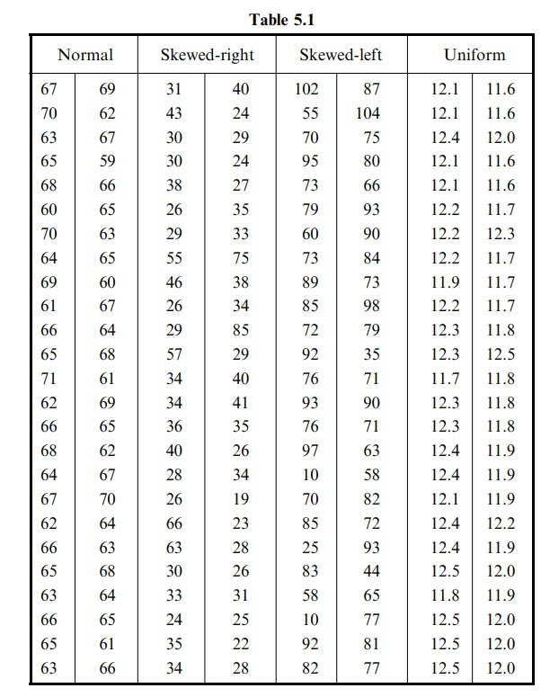

### Contextually, as follows:

> **The normal data are female height measurements**

> **The skewed-right data are age at marriage for females**

> **The skewed-left data are obituary data that give the age at death for females**

> **The uniform data are the amount of cola put into a 12 ounce container by a soft drinks machine.**

### Dataset Preview on Python

```python
import pandas as pd

# Defining the datasets
data = {
    'Normal': [67, 70, 63, 65, 68, 60, 70, 64, 69, 61, 66, 6, 71, 62, 66, 68, 64, 67, 62, 66, 65, 63, 66, 65, 63, 69, 62, 67, 59, 66, 65, 63, 65, 60, 67, 64, 68, 61, 69, 65, 62, 67, 70, 64, 63, 68, 64, 65, 61, 66],
    'Skewed-right': [31, 43, 30, 30, 38, 26, 29, 55, 46, 26, 29, 57, 34, 34, 36, 40, 28, 26, 66, 63, 30, 33, 24, 35, 34, 40, 24, 29, 24, 27, 35, 33, 75, 38, 34, 85, 29, 40, 41, 35, 26, 34, 19, 23, 28, 26, 31, 25, 22, 28],
    'Skewed-left': [102, 55, 70, 95, 73, 79, 60, 73, 89, 85, 72, 92, 76, 93, 76, 97, 10, 70, 85, 25, 83, 58, 10, 92, 82, 87, 104, 75, 80, 66, 93, 90, 84, 73, 98, 79, 35, 71, 90, 71, 63, 58, 82, 72, 93, 44, 65, 77, 81, 77],
    'Uniform': [12.1, 12.1, 12.4, 12.1, 12.1, 12.2, 12.2, 12.2, 11.9, 12.2, 12.3, 12.3, 11.7, 12.3, 12.3, 12.4, 12.4, 12.1, 12.4, 12.4, 12.5, 11.8, 12.5, 12.5, 12.5, 11.6, 11.6, 12, 11.6, 11.6, 11.7, 12.3, 11.7, 11.7, 11.7, 11.8, 12.5, 11.8, 11.8, 11.8, 11.9, 11.9, 11.9, 12.2, 11.9, 12, 11.9, 12, 12, 12]
}

# Creating a DataFrame from the data
df = pd.DataFrame(data)
df = df.rename_axis('Sample ID')

df
```

[output not shown]

## Summary of Formulas:

| Moment Degree | Raw Moment (Origin = 0) | Central Moment (Mean) |
| --- | --- | --- |
| **1st Moment** (Arithmetic Mean) | $ m'_1 = \frac{\sum_{j=1}^{N}X_{j}}{N} $ | $ m_1 = \frac{\sum_{j=1}^{N}(X_{j} - \mu)}{N} = 0 $ |
| **2nd Moment** (Variance) | $ m'_2 = \frac{\sum_{j=1}^{N}(X_{j})^2}{N} $ | $ m_2 = \frac{\sum_{j=1}^{N}(X_{j} - \mu)^2}{N} = \sigma^2 $ |
| **3rd Moment** (Skewness) | $ m'_3 = \frac{\sum_{j=1}^{N}(X_{j})^3}{N} $ | $ m_3 = \frac{\sum_{j=1}^{N}(X_{j} - \mu)^3}{N} $ |
| **4th Moment** (Kurtosis) | $ m'_4 = \frac{\sum_{j=1}^{N}(X_{j})^4}{N} $ | $ m_4 = \frac{\sum_{j=1}^{N}(X_{j} - \mu)^4}{N} $ |

## Task A: Determine the moments for each of the sets of data

```python
# Create a table to store results
results_A = {
    'Moments of Degree': [1, 2, 3, 4],
    'Normal': [],
    'Skewed-right': [],
    'Skewed-left': [],
    'Uniform': []
}

# Calculate raw moments (Origin = 0) for each series of dataset df
for moment_degree in range(1,5):
    for each_series in df.columns:
        moment_summation = 0
        for current_value in df[each_series]:
            moment_summation += current_value ** moment_degree
        result_moment = round(moment_summation/len(df[each_series]), 2)
        results_A[each_series].append(result_moment)

moment_results_A = pd.DataFrame(results_A)
moment_results_A.rename_axis('Task A Result ID')
```

| Task A Result ID | Moments of Degree | Normal | Skewed-right | Skewed-left | Uniform |
| --- | --- | --- | --- | --- | --- |
| 0 | 1 | 63.94 | 35.48 | 74.20 | 12.06 |
| 1 | 2 | 4165.14 | 1437.72 | 5925.40 | 145.43 |
| 2 | 3 | 272282.74 | 68292.44 | 489458.80 | 1755.16 |
| 3 | 4 | 17837187.06 | 3797594.04 | 41396161.48 | 21194.59 |

## Task B: Determine the moments about the mean for each of the sets of data

```python
# Create a table to store results
results_B = {
    'Central Moments of Degree': [1, 2, 3, 4],
    'Normal': [],
    'Skewed-right': [],
    'Skewed-left': [],
    'Uniform': []
}

# Calculate raw moments (Origin = 0) for each series of dataset df
for moment_degree in range(1,5):
    for each_series in df.columns:
        central_summation = 0
        each_mean = sum(df[each_series]) / len(df[each_series])
        for current_value in df[each_series]:
            central_summation += (current_value - each_mean) ** moment_degree
        result_moment = round(central_summation/len(df[each_series]), 2)
        results_B[each_series].append(result_moment)

moment_results_B = pd.DataFrame(results_B)
moment_results_B.rename_axis('Task B Result ID')
```

| Task B Result ID | Central Moments of Degree | Normal | Skewed-right | Skewed-left | Uniform |
| --- | --- | --- | --- | --- | --- |
| 0 | 1 | 0.00 | 0.00 | -0.00 | -0.00 |
| 1 | 2 | 76.82 | 178.89 | 419.76 | 0.08 |
| 2 | 3 | -3859.59 | 4588.13 | -12498.26 | 0.00 |
| 3 | 4 | 225624.86 | 210642.88 | 927289.75 | 0.01 |

#### Take Note:

- $ m_1 $ is the 1st degree central moment
- $ m_2 $ is the 2nd degree central moment
- $ m_3 $ is the 3rd degree central moment
- $ m_4 $ is the 4th degree central moment

## Task C: Determine the moments in various degrees about the number 75 for the set of female height measurements. (Origin = 75)

```python
# Create a table to store results
results_C = {
    'Raw Moments of Degree': [1, 2, 3, 4],
    'Normal': []
}

# Calculate deviated moments (Origin = 75) for the Normal series in our df
for moment_degree in range(1,5):
    deviation_summation = 0
    deviation_origin = 75
    for current_value in df['Normal']:
        deviation_summation += (current_value - deviation_origin) ** moment_degree
    result_moment = round(deviation_summation/len(df[each_series]), 2)
    results_C['Normal'].append(result_moment)

moment_results_C = pd.DataFrame(results_C)
moment_results_C.rename_axis('Task C Result ID')
```

| Task C Result ID | Raw Moments of Degree | Normal |
| --- | --- | --- |
| 0 | 1 | -11.06 |
| 1 | 2 | 199.14 |
| 2 | 3 | -7761.26 |
| 3 | 4 | 467715.06 |

#### Take Note:

- $ m'_1 $ is the 1st degree raw moment (origin = 75)
- $ m'_2 $ is the 2nd degree raw moment (origin = 75)
- $ m'_3 $ is the 3rd degree raw moment (origin = 75)
- $ m'_4 $ is the 4th degree raw moment (origin = 75)

## Task D: Using the results of items 2 and 3 for the set of female height measurements, verify the relations

#### Central Moments in item 2

$ m_1 $ $ m_2 $ $ m_3 $ $ m_4 $

#### Raw Moments in item 3 where origin = 75

$ m'_1 $ $ m'_2 $ $ m'_3 $ $ m'_4 $

#### Relations that needed verification

- $ m_2 = m'_2 - (m'_1)^2 $
- $ m_3 = m'_3 - 3(m'_1)(m'_2) + 2(m'_1)^3 $
- $ m_4 = m'_4 - 4(m'_1)(m'_3) + 6(m'_1)^2(m'_2) - 3(m'_1)^4 $

```python
# Select only 'Central Moments of Degree' and 'Normal'
filtered_results_B = moment_results_B[['Central Moments of Degree', 'Normal']]

# Function to highlight the second row
def highlight_row(row):
    return ['background-color: salmon' if row.name == 1 else '' for _ in row]

# Apply the highlighting function
styled_filtered_results_B = filtered_results_B.style.apply(highlight_row, axis=1)

# Display the styled DataFrame
styled_filtered_results_B
```

|  | Central Moments of Degree | Normal |
| --- | --- | --- |
| 0 | 1 | 0 |
| 1 | 2 | 76.82 |
| 2 | 3 | -3859.59 |
| 3 | 4 | 225625 |

#### Given:

$ m_2 = 76.82 $

```python
# Select only 'Central Moments of Degree' and 'Normal'
filtered_results_C = moment_results_C[['Raw Moments of Degree', 'Normal']]

# Function to highlight the second row
def highlight_row(row):
    return ['background-color: gold' if row.name < 2 else '' for _ in row]

# Apply the highlighting function
styled_filtered_results_C = filtered_results_C.style.apply(highlight_row, axis=1)

# Display the styled DataFrame
styled_filtered_results_C
```

|  | Raw Moments of Degree | Normal |
| --- | --- | --- |
| 0 | 1 | -11.06 |
| 1 | 2 | 199.14 |
| 2 | 3 | -7761.26 |
| 3 | 4 | 467715 |

#### Evaluate:

$ m'_2 - (m'_1)^2 $

$ = 199.14 - (-11.06)^2 $

$ = 199.14 - 122.32 $

$ = 76.82 $

$ = m_2 $

#### Therefore $ m_2 = m'_2 - (m'_1)^2 $

```python
def highlight_row(row):
    return [
        'background-color: springgreen' if row.name == 1 else
        'background-color: salmon' if row.name == 2 else
        '' for _ in row
    ]

# Apply the highlighting function
styled_filtered_results_B = filtered_results_B.style.apply(highlight_row, axis=1)

# Function to highlight the second one
def highlight_row(row):
    return ['background-color: gold' if row.name < 3 else '' for _ in row]

# Apply the highlighting function
styled_filtered_results_C = filtered_results_C.style.apply(highlight_row, axis=1)

# Display the styled DataFrame
styled_filtered_results_B
```

|  | Central Moments of Degree | Normal |
| --- | --- | --- |
| 0 | 1 | 0 |
| 1 | 2 | 76.82 |
| 2 | 3 | -3859.59 |
| 3 | 4 | 225625 |

#### Given:

$ m_3 = -3859.59 $

```python
styled_filtered_results_C
```

|  | Raw Moments of Degree | Normal |
| --- | --- | --- |
| 0 | 1 | -11.06 |
| 1 | 2 | 199.14 |
| 2 | 3 | -7761.26 |
| 3 | 4 | 467715 |

#### Evaluate:

$ m'_3 - 3(m'_1)(m'_2) + 2(m'_1)^3 $

$ = -7761.26 - 3(-11.06)(199.14) + 2(-11.06)^3 $

$ = -7761.26 + 6607.47 - 2705.80 $

$ = −3859.59 $

$ = m_3 $

#### Therefore $ m_3 = m'_3 - 3(m'_1)(m'_2) + 2(m'_1)^3 $

```python
def highlight_row(row):
    return [
        'background-color: springgreen' if row.name == 1 or row.name == 2 else
        'background-color: salmon' if row.name == 3 else
        '' for _ in row
    ]

# Apply the highlighting function
styled_filtered_results_B = filtered_results_B.style.apply(highlight_row, axis=1)

# Function to highlight the second one
def highlight_row(row):
    return ['background-color: gold' if row.name < 4 else '' for _ in row]

# Apply the highlighting function
styled_filtered_results_C = filtered_results_C.style.apply(highlight_row, axis=1)

# Display the styled DataFrame
styled_filtered_results_B
```

|  | Central Moments of Degree | Normal |
| --- | --- | --- |
| 0 | 1 | 0 |
| 1 | 2 | 76.82 |
| 2 | 3 | -3859.59 |
| 3 | 4 | 225625 |

#### Given:

$ m_4 = 225625 $

```python
styled_filtered_results_C
```

|  | Raw Moments of Degree | Normal |
| --- | --- | --- |
| 0 | 1 | -11.06 |
| 1 | 2 | 199.14 |
| 2 | 3 | -7761.26 |
| 3 | 4 | 467715 |

#### Evaluate:

$ m'_4 - 4(m'_1)(m'_3) + 6(m'_1)^2(m'_2) - 3(m'_1)^4 $

$ = 467715 - 4(-11.06)(-7761.26) + 6(-11.06)^2(199.14) - 3(-11.06)^4 $

$ = 467715 - 343358.14 + 146157.13 - 44889.19$

$ = 225624.8 \approx 225625 $ due to rounding up in the new display due to huge data content

$ = m_4 $

#### Therefore $ m_4 = m'_4 - 4(m'_1)(m'_3) + 6(m'_1)^2(m'_2) - 3(m'_1)^4 $